# Test a Perceptual Phenomenon

### Analyzing the Stroop Effect

Perform the analysis in the space below. Remember to follow [the instructions](https://docs.google.com/document/d/1-OkpZLjG_kX9J6LIQ5IltsqMzVWjh36QpnP2RYpVdPU/pub?embedded=True) and review the [project rubric](https://review.udacity.com/#!/rubrics/71/view) before submitting. Once you've completed the analysis and write up, download this file as a PDF or HTML file and submit in the next section.

(1) What is the independent variable? What is the dependent variable?

> **The independent variable is the word condition. The dependent variable is the time recorded response time to read through the word condition.**

(2) What is an appropriate set of hypotheses for this task? What kind of statistical test do you expect to perform? Justify your choices.

> Let **congruent-condition** equal the reading response time to the task in which the color word name and font color match  
> Let **incongruent-condition** equal the reading response time to the task in which the color word name and font color do not match

> **H0 - Null Hypothesis:** ( **μ**congruent-condition = **μ**incongruent-condition ) The population mean reading response time for the congruent (congruent-condition) words is *equal* to the population mean reading response time for the incongruent (incongruent-condition) words.

> **HA - Alternative Hypothesis:** ( **μ**congruent-condition ≠ **μ**incongruent-condition ) The population mean reading response time for the congruent (congruent-condition) words is *significantly different* from the population mean reading response time for the incongruent (incongruent-condition) words.

> $$H_0: μ_{congruent-condition} = μ_{incongruent-condition}$$

> $$H_A: μ_{congruent-condition} \neq μ_{incongruent-condition} $$

> **We have interval/continuous data, we are investigating the hypothesis of a difference in means, we have dependent samples, between two paired (matched) measures, and our data based on the charts below appears to be normally distrubuted therefore the appropriate test to use is the paired t-test. Additionally, z-tests are best used for larger samples where n>30. Our null hypothesis is that there is no difference between the mean response times for the congruent condition and the incongruent condition. The image below represents the decision flow for chosing the t-test.**

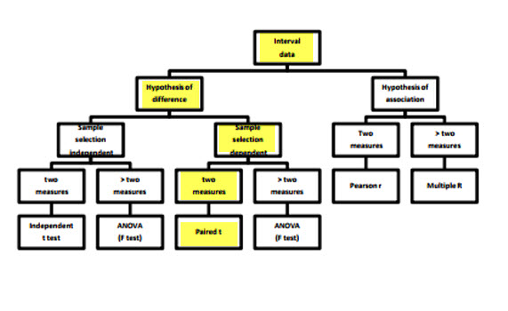

```python
from IPython.core.display import Image
Image(filename='./img/Test_Choice_Flow.jpg')
```

(3) Report some descriptive statistics regarding this dataset. Include at least one measure of central tendency and at least one measure of variability. The name of the data file is 'stroopdata.csv'.

```python
# Perform the analysis here
import pandas as pd
import numpy as np
import random
import matplotlib.pyplot as plt
import seaborn as sns
import scipy.stats as scipy
%matplotlib inline
```

```python
df = pd.read_csv('stroopdata.csv')
df.head()
```

|  | Congruent | Incongruent |
| --- | --- | --- |
| 0 | 12.079 | 19.278 |
| 1 | 16.791 | 18.741 |
| 2 | 9.564 | 21.214 |
| 3 | 8.630 | 15.687 |
| 4 | 14.669 | 22.803 |

```python
df.describe()
```

|  | Congruent | Incongruent |
| --- | --- | --- |
| count | 24.000000 | 24.000000 |
| mean | 14.051125 | 22.015917 |
| std | 3.559358 | 4.797057 |
| min | 8.630000 | 15.687000 |
| 25% | 11.895250 | 18.716750 |
| 50% | 14.356500 | 21.017500 |
| 75% | 16.200750 | 24.051500 |
| max | 22.328000 | 35.255000 |

(4) Provide one or two visualizations that show the distribution of the sample data. Write one or two sentences noting what you observe about the plot or plots.

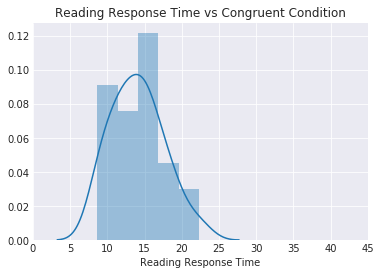

```python
sns.set_style("darkgrid")
ax=sns.distplot(df['Congruent'])
plt.xlim(0,45)
plt.title('Reading Response Time vs Congruent Condition')
ax.set_xlabel('Reading Response Time')
plt.show()
```

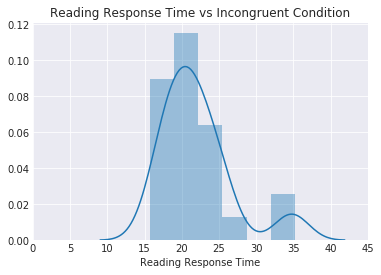

```python
sns.set_style("darkgrid")
ax=sns.distplot(df['Incongruent'])
plt.xlim(0,45)
plt.title('Reading Response Time vs Incongruent Condition')
ax.set_xlabel('Reading Response Time')
plt.show()
```

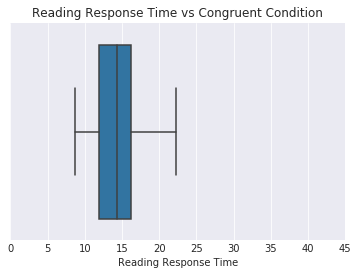

```python
sns.set_style("darkgrid")
ax=sns.boxplot(x="Congruent", data=df,orient='h')
plt.xlim(0,45)
plt.title('Reading Response Time vs Congruent Condition')
ax.set_xlabel('Reading Response Time')
plt.show()
```

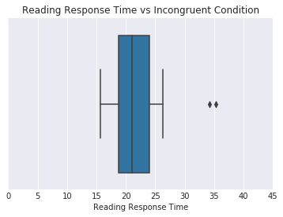

```python
sns.set_style("darkgrid")
ax=sns.boxplot(x="Incongruent", data=df,orient='h')
plt.xlim(0,45)
plt.title('Reading Response Time vs Incongruent Condition')
ax.set_xlabel('Reading Response Time')
plt.show()
```

> **Both the congruent and incongruent response times appear that they may be normally distributed, though we dont have enough data to see a nice bell curve. The box plots show that the median response time for the incongruent condition is higher (6.661 seconds higher based on the describe output)**

(5) Now, perform the statistical test and report the results. What is the confidence level and your critical statistic value? Do you reject the null hypothesis or fail to reject it? Come to a conclusion in terms of the experiment task. Did the results match up with your expectations?

```python
# Perform the statistical test here
scipy.stats.ttest_rel(df['Congruent'], df['Incongruent'])
```

```
Ttest_relResult(statistic=-8.020706944109957, pvalue=4.1030005857111781e-08)
```

> **Confidence level + alpha = 1. If we select alpha to equal .05, then we have 95% confidence level if our pvalue is less than alpha. If we allow alpha to be .01 then we have a 99% confidence level if our pvalue is less than alpha. Our t-statistic is -8.021 and our pvalue is extremely small (small pvalues are good) and less than .01 which indicates that the results did not occur by chance and that we have a better than 99% confidence level. Therefore we would reject our null hypothesis in favor of the alternate hypothesis that there is a statistically significant difference in the response rates.**

## Optional

> **The following Wiki article discusses some of the possible causes of this effect: https://en.wikipedia.org/wiki/Stroop_effect. Which in short are (1) related to the brain's processing speed, which may suggest that it reads words faster than it processes colors (2) that color recognition requires more attention (3) that color recognition is not an automatic response while the brain learns to automatically interpet the meanings of words.**

> **In a related study, the effects of sleep deprvation were tested to see if they increased the response times associated with the Stroop Effect: https://www.ncbi.nlm.nih.gov/pmc/articles/PMC4418248/. It was found that the reaction times were significantly increased after 24hours of sleep deprivation when compared to the baseline.**

## References

> The following websites were used for examples and insights

> **Websites:**  
> Z Test & T Test: Similarities & Differences  
> http://bit.ly/2DTVpca  
> Choosing the correct statistical test made easy  
> http://bit.ly/2DVgGT6  
> How to select the appropriate statistical test  
> http://bit.ly/2DoAMnF  
> The Statistics Tutor's Quick Guide to Commonly Used Statistical Tests  
> http://bit.ly/2F2gS21  
> Stat Tutor: Paired T-Test  
> http://bit.ly/2G2DgcL  
> SciPy.Org: scipy.stats.ttest_rel  
> http://bit.ly/2mWgGK8